# Case Study 2

Justin Ehly

12/5/2020

—– Executive Summary —–

This is a case study for DDSAnalytics that leverages data science for talent management. Talent management is the iterative process of developing and retaining employees and may include workforce planning, employee development through training and mentoring, increasing employee satisfaction and reducing voluntary employee attrition or churn.

The first part of this analysis focuses on attrition and utilizes a machine algorithm called Boruta to efficiently identify both statistically and highly probable statistically important factors that lead to attrition. After careful testing and modeling, it was determined that the three most influential factors contributing to attrition are overtime, monthly income and stock options.

The second part of this analysis focuses on job role trends. Based on the data, the employees seem to be on average all aobut the same when it comes to environment and job satisfaction, job involvement and work life balance with scores ranging from 2.5-3.0 on a 4 point scale. Sales Reps tend to be the youngest and have the lowest average scores in terms of satisfaction while managers tend to be the oldest and most satisfied with their jobs. Overall the company is very generous with annual pay raises with an overall average of 15.2%!

Finally, we looked at estimating monthly salaries and determined the most influential factors are total working years, education level, job level and job role.

The video presentation can be viewed here: https://www.screencast.com/t/leqSdPsrP -Justin Ehly

Online Research to help with variable selection Based on some SME online research, let’s start with 1. Poor Training - According to go2HR.com, 40% of employees who receive poor job training leave their positions within the first year. 2. Poor Management increases turnover - survey conducted by FurstPerson illustrates as much, highlighting a correlation between a director’s tenure and employee attrition. 3. Lack of Growth Opportunities 4. Inaccurate Job descriptions during hiring process (leads to disappointed employees) Resource: https://www.furstperson.com/blog/causes-employee-attrition-cost-employee-attrition

Another study shows 1. management 2. Alignment & Involvement 3. Employee Enablement 4. Collaboration & Teamwork 5. Feedback & Recognition 6. Investment in People 7. Comp & Benefits 8. Company Confidence 9. Social Connection 10. Company Performance Resource: https://blog.betterworks.com/people-analytics-reveals-top-reasons-for-attrition-and-it-isnt-compensation/

```r
##### Libraries #####
library(readr)
library(tibble)
library(ggplot2)
library(GGally)
library(magrittr)
library(plotly)
library(utils)
library(stats)
library(e1071)
library(tidyverse)
library(caret)
library(klaR)
library(mlbench)
library(rstatix)
library(fmsb)
library(class)
library(stringr)
library(Boruta)
library(dplyr)
```

```r
#####################################
##                                 ##
########### Grab the Data ###########
##                                 ##
#####################################
dds <- read.csv("CaseStudy2-data.csv")
#view(names(dds))

##### Look for any NAs in the data set ####
sapply(dds, function(x) sum(is.na(x)))
```

```
##                       ID                      Age                Attrition
##                        0                        0                        0
##           BusinessTravel                DailyRate               Department
##                        0                        0                        0
##         DistanceFromHome                Education           EducationField
##                        0                        0                        0
##            EmployeeCount           EmployeeNumber  EnvironmentSatisfaction
##                        0                        0                        0
##                   Gender               HourlyRate           JobInvolvement
##                        0                        0                        0
##                 JobLevel                  JobRole          JobSatisfaction
##                        0                        0                        0
##            MaritalStatus            MonthlyIncome              MonthlyRate
##                        0                        0                        0
##       NumCompaniesWorked                   Over18                 OverTime
##                        0                        0                        0
##        PercentSalaryHike        PerformanceRating RelationshipSatisfaction
##                        0                        0                        0
##            StandardHours         StockOptionLevel        TotalWorkingYears
##                        0                        0                        0
##    TrainingTimesLastYear          WorkLifeBalance           YearsAtCompany
##                        0                        0                        0
##       YearsInCurrentRole  YearsSinceLastPromotion     YearsWithCurrManager
##                        0                        0                        0
```

```r
# Confirmed no NA's in the data
summary(dds)
```

```
##        ID             Age         Attrition         BusinessTravel
##  Min.   :  1.0   Min.   :18.00   Length:870         Length:870
##  1st Qu.:218.2   1st Qu.:30.00   Class :character   Class :character
##  Median :435.5   Median :35.00   Mode  :character   Mode  :character
##  Mean   :435.5   Mean   :36.83
##  3rd Qu.:652.8   3rd Qu.:43.00
##  Max.   :870.0   Max.   :60.00
##    DailyRate       Department        DistanceFromHome   Education
##  Min.   : 103.0   Length:870         Min.   : 1.000   Min.   :1.000
##  1st Qu.: 472.5   Class :character   1st Qu.: 2.000   1st Qu.:2.000
##  Median : 817.5   Mode  :character   Median : 7.000   Median :3.000
##  Mean   : 815.2                      Mean   : 9.339   Mean   :2.901
##  3rd Qu.:1165.8                      3rd Qu.:14.000   3rd Qu.:4.000
##  Max.   :1499.0                      Max.   :29.000   Max.   :5.000
##  EducationField     EmployeeCount EmployeeNumber   EnvironmentSatisfaction
##  Length:870         Min.   :1     Min.   :   1.0   Min.   :1.000
##  Class :character   1st Qu.:1     1st Qu.: 477.2   1st Qu.:2.000
##  Mode  :character   Median :1     Median :1039.0   Median :3.000
##                     Mean   :1     Mean   :1029.8   Mean   :2.701
##                     3rd Qu.:1     3rd Qu.:1561.5   3rd Qu.:4.000
##                     Max.   :1     Max.   :2064.0   Max.   :4.000
##     Gender            HourlyRate     JobInvolvement     JobLevel
##  Length:870         Min.   : 30.00   Min.   :1.000   Min.   :1.000
##  Class :character   1st Qu.: 48.00   1st Qu.:2.000   1st Qu.:1.000
##  Mode  :character   Median : 66.00   Median :3.000   Median :2.000
##                     Mean   : 65.61   Mean   :2.723   Mean   :2.039
##                     3rd Qu.: 83.00   3rd Qu.:3.000   3rd Qu.:3.000
##                     Max.   :100.00   Max.   :4.000   Max.   :5.000
##    JobRole          JobSatisfaction MaritalStatus      MonthlyIncome
##  Length:870         Min.   :1.000   Length:870         Min.   : 1081
##  Class :character   1st Qu.:2.000   Class :character   1st Qu.: 2840
##  Mode  :character   Median :3.000   Mode  :character   Median : 4946
##                     Mean   :2.709                      Mean   : 6390
##                     3rd Qu.:4.000                      3rd Qu.: 8182
##                     Max.   :4.000                      Max.   :19999
##   MonthlyRate    NumCompaniesWorked    Over18            OverTime
##  Min.   : 2094   Min.   :0.000      Length:870         Length:870
##  1st Qu.: 8092   1st Qu.:1.000      Class :character   Class :character
##  Median :14074   Median :2.000      Mode  :character   Mode  :character
##  Mean   :14326   Mean   :2.728
```

[output cut: 15 more lines]

```
##  Max.   :3.0000   Max.   :40.00     Max.   :6.000         Max.   :4.000
##  YearsAtCompany   YearsInCurrentRole YearsSinceLastPromotion
##  Min.   : 0.000   Min.   : 0.000     Min.   : 0.000
##  1st Qu.: 3.000   1st Qu.: 2.000     1st Qu.: 0.000
##  Median : 5.000   Median : 3.000     Median : 1.000
##  Mean   : 6.962   Mean   : 4.205     Mean   : 2.169
##  3rd Qu.:10.000   3rd Qu.: 7.000     3rd Qu.: 3.000
##  Max.   :40.000   Max.   :18.000     Max.   :15.000
##  YearsWithCurrManager
##  Min.   : 0.00
##  1st Qu.: 2.00
##  Median : 3.00
##  Mean   : 4.14
##  3rd Qu.: 7.00
##  Max.   :17.00
```

```r
# Get a list of all variable names and unique values
dds_info <- capture.output(str(dds))
#view(dds_info)
write(dds_info, "dds_info.csv")
```

```r
#########################################################
#                                                       #
################# Categorical Variables #################
#                                                       #
#########################################################

# Let's separate the categorical from the numeric variables and get rid of unnecessary variables
# I used excel for this part
# Categorical Variables
ddsDF_cat <- dds[,c(3,4,6,8,9,12,13,15:19,24,26,27,29,31,32)]
str(ddsDF_cat)
```

```
## 'data.frame':    870 obs. of  18 variables:
##  $ Attrition               : chr  "No" "No" "No" "No" ...
##  $ BusinessTravel          : chr  "Travel_Rarely" "Travel_Rarely" "Travel_Frequently" "Travel_Rarely" ...
##  $ Department              : chr  "Sales" "Research & Development" "Research & Development" "Sales" ...
##  $ Education               : int  4 3 2 4 1 2 5 4 4 4 ...
##  $ EducationField          : chr  "Life Sciences" "Medical" "Life Sciences" "Marketing" ...
##  $ EnvironmentSatisfaction : int  2 3 3 3 1 4 2 4 3 4 ...
##  $ Gender                  : chr  "Male" "Male" "Male" "Female" ...
##  $ JobInvolvement          : int  3 2 3 3 3 3 4 2 3 2 ...
##  $ JobLevel                : int  2 5 3 3 1 3 1 2 1 2 ...
##  $ JobRole                 : chr  "Sales Executive" "Research Director" "Manufacturing Director" "Sales Executive" ...
##  $ JobSatisfaction         : int  4 3 4 4 4 1 3 4 3 3 ...
##  $ MaritalStatus           : chr  "Divorced" "Single" "Single" "Married" ...
##  $ OverTime                : chr  "No" "No" "No" "No" ...
##  $ PerformanceRating       : int  3 3 3 3 3 4 3 3 3 3 ...
##  $ RelationshipSatisfaction: int  3 1 3 3 3 3 1 3 4 2 ...
##  $ StockOptionLevel        : int  1 0 0 2 0 2 0 3 1 1 ...
##  $ TrainingTimesLastYear   : int  3 2 2 3 2 4 5 5 2 3 ...
##  $ WorkLifeBalance         : int  2 4 3 3 3 2 2 3 3 2 ...
```

```r
# let's turn all the variables into factors
ddsDF_cat <- ddsDF_cat %>% dplyr::mutate_if(is.character, as.factor)
ddsDF_cat <- ddsDF_cat %>% dplyr::mutate_if(is.integer, as.factor)

ddsDF_cat$JobRole <- case_when(
  ddsDF_cat$JobRole == "Healthcare Representative" ~ "Healthcare Rep",
  ddsDF_cat$JobRole == "Human Resources" ~ "HR",
  ddsDF_cat$JobRole == "Laboratory Technician" ~ "Lab Tech",
  ddsDF_cat$JobRole == "Manufacturing Director" ~ "Manufact Director",
  ddsDF_cat$JobRole == "Research Director" ~ "Res. Director",
  ddsDF_cat$JobRole == "Research Scientist" ~ "Res. Scientist",
  ddsDF_cat$JobRole == "Sales Executive" ~ "Sales Exec",
  ddsDF_cat$JobRole == "Sales Representative" ~ "Sales Rep",
  ddsDF_cat$JobRole == "Manager" ~ "Manager")

str(ddsDF_cat)
```

```
## 'data.frame':    870 obs. of  18 variables:
##  $ Attrition               : Factor w/ 2 levels "No","Yes": 1 1 1 1 1 1 1 1 1 1 ...
##  $ BusinessTravel          : Factor w/ 3 levels "Non-Travel","Travel_Frequently",..: 3 3 2 3 2 2 3 3 3 2 ...
##  $ Department              : Factor w/ 3 levels "Human Resources",..: 3 2 2 3 2 2 2 3 3 2 ...
##  $ Education               : Factor w/ 5 levels "1","2","3","4",..: 4 3 2 4 1 2 5 4 4 4 ...
##  $ EducationField          : Factor w/ 6 levels "Human Resources",..: 2 4 2 3 6 2 4 2 2 6 ...
##  $ EnvironmentSatisfaction : Factor w/ 4 levels "1","2","3","4": 2 3 3 3 1 4 2 4 3 4 ...
##  $ Gender                  : Factor w/ 2 levels "Female","Male": 2 2 2 1 1 2 2 1 1 2 ...
##  $ JobInvolvement          : Factor w/ 4 levels "1","2","3","4": 3 2 3 3 3 3 4 2 3 2 ...
##  $ JobLevel                : Factor w/ 5 levels "1","2","3","4",..: 2 5 3 3 1 3 1 2 1 2 ...
##  $ JobRole                 : chr  "Sales Exec" "Res. Director" "Manufact Director" "Sales Exec" ...
##  $ JobSatisfaction         : Factor w/ 4 levels "1","2","3","4": 4 3 4 4 4 1 3 4 3 3 ...
##  $ MaritalStatus           : Factor w/ 3 levels "Divorced","Married",..: 1 3 3 2 3 1 2 1 2 2 ...
##  $ OverTime                : Factor w/ 2 levels "No","Yes": 1 1 1 1 2 1 2 2 2 1 ...
##  $ PerformanceRating       : Factor w/ 2 levels "3","4": 1 1 1 1 1 2 1 1 1 1 ...
##  $ RelationshipSatisfaction: Factor w/ 4 levels "1","2","3","4": 3 1 3 3 3 3 1 3 4 2 ...
##  $ StockOptionLevel        : Factor w/ 4 levels "0","1","2","3": 2 1 1 3 1 3 1 4 2 2 ...
##  $ TrainingTimesLastYear   : Factor w/ 7 levels "0","1","2","3",..: 4 3 3 4 3 5 6 6 3 4 ...
##  $ WorkLifeBalance         : Factor w/ 4 levels "1","2","3","4": 2 4 3 3 3 2 2 3 3 2 ...
```

```r
###############################################
#                                             #
############# Numeric Variables ###############
#                                             #
###############################################

# numeric variables
ddsDF_num <- dds[,c(3,2,5,7,14,20,21,22,25,30,33:36)]
str(ddsDF_num)
```

```
## 'data.frame':    870 obs. of  14 variables:
##  $ Attrition              : chr  "No" "No" "No" "No" ...
##  $ Age                    : int  32 40 35 32 24 27 41 37 34 34 ...
##  $ DailyRate              : int  117 1308 200 801 567 294 1283 309 1333 653 ...
##  $ DistanceFromHome       : int  13 14 18 1 2 10 5 10 10 10 ...
##  $ HourlyRate             : int  73 44 60 48 32 32 90 88 87 92 ...
##  $ MonthlyIncome          : int  4403 19626 9362 10422 3760 8793 2127 6694 2220 5063 ...
##  $ MonthlyRate            : int  9250 17544 19944 24032 17218 4809 5561 24223 18410 15332 ...
##  $ NumCompaniesWorked     : int  2 1 2 1 1 1 2 2 1 1 ...
##  $ PercentSalaryHike      : int  11 14 11 19 13 21 12 14 19 14 ...
##  $ TotalWorkingYears      : int  8 21 10 14 6 9 7 8 1 8 ...
##  $ YearsAtCompany         : int  5 20 2 14 6 9 4 1 1 8 ...
##  $ YearsInCurrentRole     : int  2 7 2 10 3 7 2 0 1 2 ...
##  $ YearsSinceLastPromotion: int  0 4 2 5 1 1 0 0 0 7 ...
##  $ YearsWithCurrManager   : int  3 9 2 7 3 7 3 0 0 7 ...
```

```r
ddsDF_num[,c(2:14)] <- sapply(ddsDF_num[,c(2:14)], as.numeric)
ddsDF_num$Attrition <- as.factor(ddsDF_num$Attrition)
str(ddsDF_num)
```

```
## 'data.frame':    870 obs. of  14 variables:
##  $ Attrition              : Factor w/ 2 levels "No","Yes": 1 1 1 1 1 1 1 1 1 1 ...
##  $ Age                    : num  32 40 35 32 24 27 41 37 34 34 ...
##  $ DailyRate              : num  117 1308 200 801 567 ...
##  $ DistanceFromHome       : num  13 14 18 1 2 10 5 10 10 10 ...
##  $ HourlyRate             : num  73 44 60 48 32 32 90 88 87 92 ...
##  $ MonthlyIncome          : num  4403 19626 9362 10422 3760 ...
##  $ MonthlyRate            : num  9250 17544 19944 24032 17218 ...
##  $ NumCompaniesWorked     : num  2 1 2 1 1 1 2 2 1 1 ...
##  $ PercentSalaryHike      : num  11 14 11 19 13 21 12 14 19 14 ...
##  $ TotalWorkingYears      : num  8 21 10 14 6 9 7 8 1 8 ...
##  $ YearsAtCompany         : num  5 20 2 14 6 9 4 1 1 8 ...
##  $ YearsInCurrentRole     : num  2 7 2 10 3 7 2 0 1 2 ...
##  $ YearsSinceLastPromotion: num  0 4 2 5 1 1 0 0 0 7 ...
##  $ YearsWithCurrManager   : num  3 9 2 7 3 7 3 0 0 7 ...
```

```r
########################
##                    ##
###    Start EDA     ###
##                    ##
########################

################# Boruta for Attrition ##############
# Note about Boruta: Boruta is an all relevant feature selection wrapper algorithm, capable of working with any classification method that output variable importance measure (VIM); by default, Boruta uses Random Forest. The method performs a top-down search for relevant features by comparing original attributes' importance with importance achievable at random, estimated using their permuted copies, and progressively eliminating irrelevant features to stabilise that test.

ddsBinded <- cbind(ddsDF_cat, ddsDF_num)
str(ddsBinded)
```

```
## 'data.frame':    870 obs. of  32 variables:
##  $ Attrition               : Factor w/ 2 levels "No","Yes": 1 1 1 1 1 1 1 1 1 1 ...
##  $ BusinessTravel          : Factor w/ 3 levels "Non-Travel","Travel_Frequently",..: 3 3 2 3 2 2 3 3 3 2 ...
##  $ Department              : Factor w/ 3 levels "Human Resources",..: 3 2 2 3 2 2 2 3 3 2 ...
##  $ Education               : Factor w/ 5 levels "1","2","3","4",..: 4 3 2 4 1 2 5 4 4 4 ...
##  $ EducationField          : Factor w/ 6 levels "Human Resources",..: 2 4 2 3 6 2 4 2 2 6 ...
##  $ EnvironmentSatisfaction : Factor w/ 4 levels "1","2","3","4": 2 3 3 3 1 4 2 4 3 4 ...
##  $ Gender                  : Factor w/ 2 levels "Female","Male": 2 2 2 1 1 2 2 1 1 2 ...
##  $ JobInvolvement          : Factor w/ 4 levels "1","2","3","4": 3 2 3 3 3 3 4 2 3 2 ...
##  $ JobLevel                : Factor w/ 5 levels "1","2","3","4",..: 2 5 3 3 1 3 1 2 1 2 ...
##  $ JobRole                 : chr  "Sales Exec" "Res. Director" "Manufact Director" "Sales Exec" ...
##  $ JobSatisfaction         : Factor w/ 4 levels "1","2","3","4": 4 3 4 4 4 1 3 4 3 3 ...
##  $ MaritalStatus           : Factor w/ 3 levels "Divorced","Married",..: 1 3 3 2 3 1 2 1 2 2 ...
##  $ OverTime                : Factor w/ 2 levels "No","Yes": 1 1 1 1 2 1 2 2 2 1 ...
##  $ PerformanceRating       : Factor w/ 2 levels "3","4": 1 1 1 1 1 2 1 1 1 1 ...
```

[output cut: 18 more lines]

```r
names(ddsBinded)
```

```
##  [1] "Attrition"                "BusinessTravel"
##  [3] "Department"               "Education"
##  [5] "EducationField"           "EnvironmentSatisfaction"
##  [7] "Gender"                   "JobInvolvement"
##  [9] "JobLevel"                 "JobRole"
## [11] "JobSatisfaction"          "MaritalStatus"
## [13] "OverTime"                 "PerformanceRating"
## [15] "RelationshipSatisfaction" "StockOptionLevel"
## [17] "TrainingTimesLastYear"    "WorkLifeBalance"
## [19] "Attrition"                "Age"
## [21] "DailyRate"                "DistanceFromHome"
## [23] "HourlyRate"               "MonthlyIncome"
## [25] "MonthlyRate"              "NumCompaniesWorked"
## [27] "PercentSalaryHike"        "TotalWorkingYears"
## [29] "YearsAtCompany"           "YearsInCurrentRole"
## [31] "YearsSinceLastPromotion"  "YearsWithCurrManager"
```

```r
ddsBinded <- ddsBinded[,-19]

boruta_output <- Boruta(Attrition~., data=ddsBinded, doTrace=2) # Boruta search
```

```
##  1. run of importance source...
```

```
##  2. run of importance source...
```

```
##  3. run of importance source...
```

```
##  4. run of importance source...
```

```
##  5. run of importance source...
```

```
##  6. run of importance source...
```

```
##  7. run of importance source...
```

```
##  8. run of importance source...
```

```
##  9. run of importance source...
```

```
##  10. run of importance source...
```

```
##  11. run of importance source...
```

```
##  12. run of importance source...
```

```
## After 12 iterations, +1.7 secs:
```

```
##  confirmed 12 attributes: Age, JobInvolvement, JobLevel, JobRole, MaritalStatus and 7 more;
```

```
##  rejected 6 attributes: BusinessTravel, Gender, HourlyRate, MonthlyRate, PerformanceRating and 1 more;
```

```
##  still have 12 attributes left.
```

```
##  13. run of importance source...
```

```
##  14. run of importance source...
```

```
##  15. run of importance source...
```

```
##  16. run of importance source...
```

```
## After 16 iterations, +2.2 secs:
```

```
##  rejected 2 attributes: DailyRate, DistanceFromHome;
```

```
##  still have 10 attributes left.
```

```
##  17. run of importance source...
```

```
##  18. run of importance source...
```

```
##  19. run of importance source...
```

```
##  20. run of importance source...
```

```
## After 20 iterations, +2.6 secs:
```

```
##  rejected 1 attribute: Education;
```

```
##  still have 9 attributes left.
```

```
##  21. run of importance source...
```

```
##  22. run of importance source...
```

```
##  23. run of importance source...
```

```
## After 23 iterations, +2.9 secs:
```

```
##  rejected 1 attribute: YearsSinceLastPromotion;
```

```
##  still have 8 attributes left.
```

```
##  24. run of importance source...
```

```
##  25. run of importance source...
```

```
##  26. run of importance source...
```

```
## After 26 iterations, +3.2 secs:
```

```
##  confirmed 1 attribute: WorkLifeBalance;
```

```
##  still have 7 attributes left.
```

```
##  27. run of importance source...
```

```
##  28. run of importance source...
```

```
##  29. run of importance source...
```

```
## After 29 iterations, +3.6 secs:
```

```
##  rejected 2 attributes: EducationField, RelationshipSatisfaction;
```

```
##  still have 5 attributes left.
```

```
##  30. run of importance source...
```

```
##  31. run of importance source...
```

```
##  32. run of importance source...
```

```
## After 32 iterations, +3.8 secs:
```

```
##  rejected 1 attribute: PercentSalaryHike;
```

```
##  still have 4 attributes left.
```

```
##  33. run of importance source...
```

```
##  34. run of importance source...
```

```
##  35. run of importance source...
```

```
##  36. run of importance source...
```

```
##  37. run of importance source...
```

```
##  38. run of importance source...
```

```
##  39. run of importance source...
```

```
##  40. run of importance source...
```

```
##  41. run of importance source...
```

```
##  42. run of importance source...
```

```
##  43. run of importance source...
```

```
##  44. run of importance source...
```

```
##  45. run of importance source...
```

```
##  46. run of importance source...
```

```
##  47. run of importance source...
```

```
##  48. run of importance source...
```

```
##  49. run of importance source...
```

```
##  50. run of importance source...
```

```
##  51. run of importance source...
```

```
##  52. run of importance source...
```

```
##  53. run of importance source...
```

```
##  54. run of importance source...
```

```
##  55. run of importance source...
```

```
##  56. run of importance source...
```

```
##  57. run of importance source...
```

```
##  58. run of importance source...
```

```
##  59. run of importance source...
```

```
##  60. run of importance source...
```

```
##  61. run of importance source...
```

```
##  62. run of importance source...
```

```
##  63. run of importance source...
```

```
##  64. run of importance source...
```

```
##  65. run of importance source...
```

```
##  66. run of importance source...
```

```
##  67. run of importance source...
```

```
##  68. run of importance source...
```

```
##  69. run of importance source...
```

```
##  70. run of importance source...
```

```
##  71. run of importance source...
```

```
##  72. run of importance source...
```

```
##  73. run of importance source...
```

```
##  74. run of importance source...
```

```
## After 74 iterations, +7.7 secs:
```

```
##  confirmed 1 attribute: Department;
```

```
##  still have 3 attributes left.
```

```
##  75. run of importance source...
```

```
##  76. run of importance source...
```

```
##  77. run of importance source...
```

```
##  78. run of importance source...
```

```
##  79. run of importance source...
```

```
##  80. run of importance source...
```

```
##  81. run of importance source...
```

```
##  82. run of importance source...
```

```
##  83. run of importance source...
```

```
##  84. run of importance source...
```

```
##  85. run of importance source...
```

```
##  86. run of importance source...
```

```
##  87. run of importance source...
```

```
##  88. run of importance source...
```

```
##  89. run of importance source...
```

```
##  90. run of importance source...
```

```
##  91. run of importance source...
```

```
##  92. run of importance source...
```

```
##  93. run of importance source...
```

```
##  94. run of importance source...
```

```
##  95. run of importance source...
```

```
##  96. run of importance source...
```

```
##  97. run of importance source...
```

```
##  98. run of importance source...
```

```
##  99. run of importance source...
```

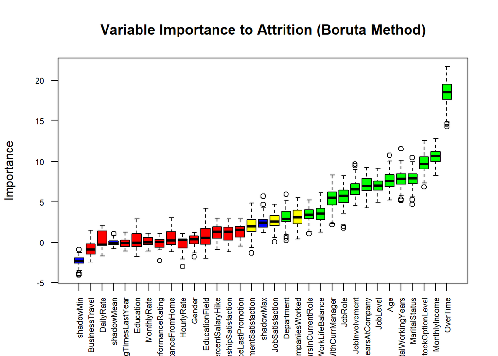

```r
boruta_signif <- names(boruta_output$finalDecision[boruta_output$finalDecision %in% c("Confirmed", "Tentative")]) #collect Confirmed and Tentative variables

#view(boruta_signif) #view sig var
# Results
# 1. Department
# 2. EnvironmentSatisfaction
# 3. JobInvolvement
# 4. JobLevel
# 5. JobRole
# 6. JobSatisfaction
# 7. MaritalStatus
# 8. OverTime
# 9. StockOptionLevel
# 10. WorkLifeBalance
# 11. Age
# 12 MonthlyIncome
# 13 NumCompaniesWorked
# 14 TotalWorkingYears
# 15 YearsAtCompany
# 16 YearsInCurrentRole
# 17 YearsSinceLastPromotion
# 18 YearsWithCurrManager

plot(boruta_output, cex.axis=.7, las=2, xlab="",
     main="Variable Importance to Attrition (Boruta Method)") #plot results
```

```r
# Top 3
# 1. Overtime
# 2. MonthlyIncome
# 3. StockOptionLevel

####### Additional EDA Based on Boruta Results and Personal Interest #####

fritos <- ddsBinded[,c("Attrition",
                       "Department",
                       "EnvironmentSatisfaction",
                       "JobInvolvement",
                       "JobLevel",
                       "JobRole",
                       "JobSatisfaction",
                       "MaritalStatus",
                       "OverTime",
                       "StockOptionLevel",
                       "WorkLifeBalance",
                       "Age",
                       "MonthlyIncome",
                       "NumCompaniesWorked",
                       "TotalWorkingYears",
                       "YearsAtCompany",
                       "YearsInCurrentRole",
                       "YearsSinceLastPromotion",
                       "YearsWithCurrManager")]
str(fritos)
```

```
## 'data.frame':    870 obs. of  19 variables:
##  $ Attrition              : Factor w/ 2 levels "No","Yes": 1 1 1 1 1 1 1 1 1 1 ...
##  $ Department             : Factor w/ 3 levels "Human Resources",..: 3 2 2 3 2 2 2 3 3 2 ...
##  $ EnvironmentSatisfaction: Factor w/ 4 levels "1","2","3","4": 2 3 3 3 1 4 2 4 3 4 ...
##  $ JobInvolvement         : Factor w/ 4 levels "1","2","3","4": 3 2 3 3 3 3 4 2 3 2 ...
##  $ JobLevel               : Factor w/ 5 levels "1","2","3","4",..: 2 5 3 3 1 3 1 2 1 2 ...
##  $ JobRole                : chr  "Sales Exec" "Res. Director" "Manufact Director" "Sales Exec" ...
##  $ JobSatisfaction        : Factor w/ 4 levels "1","2","3","4": 4 3 4 4 4 1 3 4 3 3 ...
##  $ MaritalStatus          : Factor w/ 3 levels "Divorced","Married",..: 1 3 3 2 3 1 2 1 2 2 ...
##  $ OverTime               : Factor w/ 2 levels "No","Yes": 1 1 1 1 2 1 2 2 2 1 ...
##  $ StockOptionLevel       : Factor w/ 4 levels "0","1","2","3": 2 1 1 3 1 3 1 4 2 2 ...
##  $ WorkLifeBalance        : Factor w/ 4 levels "1","2","3","4": 2 4 3 3 3 2 2 3 3 2 ...
##  $ Age                    : num  32 40 35 32 24 27 41 37 34 34 ...
##  $ MonthlyIncome          : num  4403 19626 9362 10422 3760 ...
##  $ NumCompaniesWorked     : num  2 1 2 1 1 1 2 2 1 1 ...
##  $ TotalWorkingYears      : num  8 21 10 14 6 9 7 8 1 8 ...
##  $ YearsAtCompany         : num  5 20 2 14 6 9 4 1 1 8 ...
##  $ YearsInCurrentRole     : num  2 7 2 10 3 7 2 0 1 2 ...
##  $ YearsSinceLastPromotion: num  0 4 2 5 1 1 0 0 0 7 ...
##  $ YearsWithCurrManager   : num  3 9 2 7 3 7 3 0 0 7 ...
```

```r
# Let's see how these 18 factors stack up together for significance
glmTest <- glm(Attrition~., data=fritos, family = binomial)
summary(glmTest)
```

```
##
## Call:
## glm(formula = Attrition ~ ., family = binomial, data = fritos)
##
## Deviance Residuals:
##     Min       1Q   Median       3Q      Max
## -2.1993  -0.4391  -0.1961  -0.0541   3.5362
##
## Coefficients:
##                                    Estimate Std. Error z value Pr(>|z|)
## (Intercept)                      -1.016e+01  7.420e+02  -0.014 0.989075
## DepartmentResearch & Development  1.390e+01  7.420e+02   0.019 0.985058
## DepartmentSales                   1.398e+01  7.420e+02   0.019 0.984965
## EnvironmentSatisfaction2         -1.385e+00  3.966e-01  -3.492 0.000479 ***
## EnvironmentSatisfaction3         -1.096e+00  3.508e-01  -3.123 0.001789 **
## EnvironmentSatisfaction4         -1.135e+00  3.503e-01  -3.241 0.001190 **
## JobInvolvement2                  -1.470e+00  4.743e-01  -3.099 0.001941 **
## JobInvolvement3                  -2.043e+00  4.495e-01  -4.545 5.49e-06 ***
## JobInvolvement4                  -2.051e+00  6.179e-01  -3.320 0.000901 ***
## JobLevel2                        -8.189e-01  6.531e-01  -1.254 0.209888
## JobLevel3                         7.751e-01  1.012e+00   0.766 0.443921
## JobLevel4                         4.051e-01  1.691e+00   0.240 0.810714
## JobLevel5                         4.246e+00  2.226e+00   1.907 0.056478 .
## JobRoleHR                         1.422e+01  7.420e+02   0.019 0.984709
## JobRoleLab Tech                   4.336e-02  7.550e-01   0.057 0.954200
## JobRoleManager                   -1.184e+00  1.463e+00  -0.809 0.418305
## JobRoleManufact Director         -1.315e+00  8.847e-01  -1.486 0.137234
## JobRoleRes. Director             -3.042e+00  1.571e+00  -1.936 0.052824 .
## JobRoleRes. Scientist            -4.952e-01  7.654e-01  -0.647 0.517666
## JobRoleSales Exec                 4.880e-01  1.431e+00   0.341 0.732986
## JobRoleSales Rep                  1.113e+00  1.554e+00   0.717 0.473630
## JobSatisfaction2                 -5.991e-01  3.777e-01  -1.586 0.112701
## JobSatisfaction3                 -5.090e-01  3.348e-01  -1.520 0.128489
## JobSatisfaction4                 -1.524e+00  3.714e-01  -4.102 4.09e-05 ***
## MaritalStatusMarried              1.219e+00  4.310e-01   2.828 0.004687 **
## MaritalStatusSingle               1.172e+00  5.597e-01   2.093 0.036308 *
## OverTimeYes                       2.229e+00  2.754e-01   8.094 5.77e-16 ***
## StockOptionLevel1                -1.233e+00  4.033e-01  -3.056 0.002240 **
## StockOptionLevel2                -1.309e+00  7.150e-01  -1.830 0.067207 .
## StockOptionLevel3                 3.554e-01  5.710e-01   0.622 0.533695
## WorkLifeBalance2                 -1.397e+00  4.887e-01  -2.858 0.004262 **
## WorkLifeBalance3                 -1.794e+00  4.601e-01  -3.899 9.64e-05 ***
## WorkLifeBalance4                 -2.099e+00  5.983e-01  -3.508 0.000451 ***
## Age                              -3.178e-02  1.822e-02  -1.744 0.081110 .
## MonthlyIncome                    -1.295e-04  1.335e-04  -0.970 0.331800
## NumCompaniesWorked                1.801e-01  5.363e-02   3.357 0.000787 ***
## TotalWorkingYears                -6.153e-02  4.267e-02  -1.442 0.149317
## YearsAtCompany                    5.280e-02  5.670e-02   0.931 0.351733
## YearsInCurrentRole               -1.040e-01  6.795e-02  -1.530 0.125941
## YearsSinceLastPromotion           2.540e-01  6.393e-02   3.973 7.10e-05 ***
## YearsWithCurrManager             -1.555e-01  6.521e-02  -2.385 0.017085 *
## ---
## Signif. codes:  0 '***' 0.001 '**' 0.01 '*' 0.05 '.' 0.1 ' ' 1
##
## (Dispersion parameter for binomial family taken to be 1)
##
##     Null deviance: 767.67  on 869  degrees of freedom
## Residual deviance: 455.40  on 829  degrees of freedom
## AIC: 537.4
##
## Number of Fisher Scoring iterations: 15
```

```r
car::vif(glmTest)
```

```
##                                 GVIF Df GVIF^(1/(2*Df))
## Department              4.845337e+07  2       83.431681
## EnvironmentSatisfaction 1.324113e+00  3        1.047902
## JobInvolvement          1.262361e+00  3        1.039594
## JobLevel                1.255047e+02  4        1.829500
## JobRole                 1.535226e+09  8        3.750902
## JobSatisfaction         1.338698e+00  3        1.049817
## MaritalStatus           2.839925e+00  2        1.298155
## OverTime                1.302421e+00  1        1.141236
## StockOptionLevel        2.966410e+00  3        1.198685
## WorkLifeBalance         1.369853e+00  3        1.053850
## Age                     1.812045e+00  1        1.346122
## MonthlyIncome           1.910313e+01  1        4.370712
## NumCompaniesWorked      1.499120e+00  1        1.224386
## TotalWorkingYears       5.742731e+00  1        2.396400
## YearsAtCompany          7.225288e+00  1        2.687990
## YearsInCurrentRole      3.274701e+00  1        1.809613
## YearsSinceLastPromotion 3.153323e+00  1        1.775760
## YearsWithCurrManager    3.088774e+00  1        1.757491
```

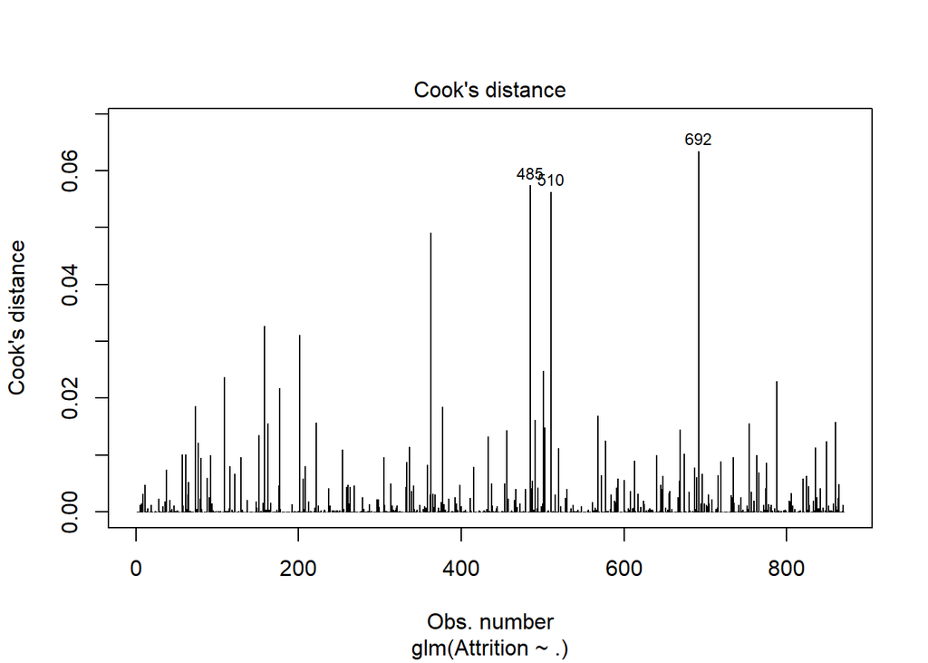

```r
plot(glmTest, which=4) # Cook's d plot
```

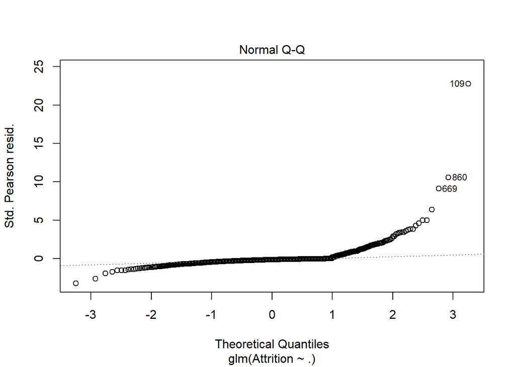

```r
plot(glmTest, which=2) # Normal Q-Q Plot
```

```r
############################################################
```

```r
############################################################
##                                                        ##
##              T-test and Chi-Sq Tests                   ##
##                                                        ##
############################################################

# t-Test Independent Numerical Variables vs Attrition
age <- t.test(ddsBinded$Age~ddsBinded$Attrition)
dayrate <- t.test(ddsBinded$DailyRate~ddsBinded$Attrition)
disthom <- t.test(ddsBinded$DistanceFromHome~ddsBinded$Attrition)
hrrt <- t.test(ddsBinded$HourlyRate~ddsBinded$Attrition)
moninc <- t.test(ddsBinded$MonthlyIncome~ddsBinded$Attrition)
numcowrk <- t.test(ddsBinded$NumCompaniesWorked~ddsBinded$Attrition)
percSal <- t.test(ddsBinded$PercentSalaryHike~ddsBinded$Attrition)
totwork <- t.test(ddsBinded$TotalWorkingYears~ddsBinded$Attrition)
yrsco <- t.test(ddsBinded$YearsAtCompany~ddsBinded$Attrition)
yrsinrole <- t.test(ddsBinded$YearsInCurrentRole~ddsBinded$Attrition)

tTestdf <- data.frame(Attrition = c("Age", "DayRate", "DistanceFromHome", "HourlyRate", "MonthlyIncome", "NumCompaniesWorked","PercentSalaryHike", "TotalWorkingYears", "YearsAtCompany","YearsInCurrentRole"),
                      statistic = c(age$statistic,dayrate$statistic,disthom$statistic,hrrt$statistic,moninc$statistic,
                           numcowrk$statistic,percSal$statistic,totwork$statistic,yrsco$statistic,yrsinrole$statistic),
                      parameter = c(age$parameter,dayrate$parameter,disthom$parameter,hrrt$parameter,moninc$parameter,
                           numcowrk$parameter,percSal$parameter,totwork$parameter,yrsco$parameter,yrsinrole$parameter),
                      pvalue = c(age$p.value,dayrate$p.value,disthom$p.value,hrrt$p.value,moninc$p.value,
                      numcowrk$p.value,percSal$p.value,totwork$p.value,yrsco$p.value,yrsinrole$p.value))


# Test Multiple variables against Attrition
features1 <- ddsBinded %>% select_if(is.numeric) %>%
  pivot_longer(., cols=c(2:13), names_to = "variable", values_to="value") #Combine Numeric Variables into a stack
features1 <- cbind(ddsBinded$Attrition, features1) # add Attrition into the dataframe
names(features1)[1] <- "Attrition" #correct column name
str(features1)
```

```
## 'data.frame':    10440 obs. of  4 variables:
##  $ Attrition: Factor w/ 2 levels "No","Yes": 1 1 1 1 1 1 1 1 1 1 ...
##  $ Age      : num  32 32 32 32 32 32 32 32 32 32 ...
##  $ variable : chr  "DailyRate" "DistanceFromHome" "HourlyRate" "MonthlyIncome" ...
##  $ value    : num  117 13 73 4403 9250 ...
```

```r
stat.test <- features1 %>% group_by(variable) %>%
  t_test(value~Attrition) %>%
  adjust_pvalue(method = "bonferroni") %>%
  add_significance()


# Chi-Square Tests for categorical variables vs Attrition
bt <- chisq.test(table(ddsBinded$Attrition, ddsBinded$BusinessTravel))
dep <- chisq.test(table(ddsBinded$Attrition,ddsBinded$Department))
edu <- chisq.test(table(ddsBinded$Attrition,ddsBinded$Education))
edufie <- chisq.test(table(ddsBinded$Attrition,ddsBinded$EducationField))
envsat <- chisq.test(table(ddsBinded$Attrition,ddsBinded$EnvironmentSatisfaction))
gender <- chisq.test(table(ddsBinded$Attrition,ddsBinded$Gender))
jobinv <- chisq.test(table(ddsBinded$Attrition,ddsBinded$JobInvolvement))
joblev <- chisq.test(table(ddsBinded$Attrition,ddsBinded$JobLevel))
jobro <- chisq.test(table(ddsBinded$Attrition,ddsBinded$JobRole))
jobsat <- chisq.test(table(ddsBinded$Attrition,ddsBinded$JobSatisfaction))
marstat <- chisq.test(table(ddsBinded$Attrition,ddsBinded$MaritalStatus))
OvrT <- chisq.test(table(ddsBinded$Attrition,ddsBinded$OverTime))
perrat <- chisq.test(table(ddsBinded$Attrition,ddsBinded$PerformanceRating))
relsat <- chisq.test(table(ddsBinded$Attrition,ddsBinded$RelationshipSatisfaction))
stoop <- chisq.test(table(ddsBinded$Attrition,ddsBinded$StockOptionLevel))
ttly <- chisq.test(table(ddsBinded$Attrition,ddsBinded$TrainingTimesLastYear))
wlb <- chisq.test(table(ddsBinded$Attrition,ddsBinded$WorkLifeBalance))
dailyrate <- chisq.test(table(ddsBinded$Attrition,ddsBinded$DailyRate))
moninc <- chisq.test(table(ddsBinded$Attrition, ddsBinded$MonthlyIncome))
namesDF <- names(ddsDF_cat)
namesDF <- namesDF[-1]
namesDF
```

```
##  [1] "BusinessTravel"           "Department"
##  [3] "Education"                "EducationField"
##  [5] "EnvironmentSatisfaction"  "Gender"
##  [7] "JobInvolvement"           "JobLevel"
##  [9] "JobRole"                  "JobSatisfaction"
## [11] "MaritalStatus"            "OverTime"
## [13] "PerformanceRating"        "RelationshipSatisfaction"
## [15] "StockOptionLevel"         "TrainingTimesLastYear"
## [17] "WorkLifeBalance"
```

```r
# dataframe of ChiSquared Pvalues
ChiDF <- data.frame(pvalue = c(bt$p.value, dep$p.value, edu$p.value, edufie$p.value, envsat$p.value, gender$p.value,
                               jobinv$p.value, joblev$p.value, jobro$p.value, jobsat$p.value, marstat$p.value,
                               OvrT$p.value, perrat$p.value, relsat$p.value, stoop$p.value, ttly$p.value, wlb$p.value),
                    parameter = c(bt$parameter, dep$parameter, edu$parameter, edufie$parameter, envsat$parameter,
                                  gender$parameter, jobinv$parameter, joblev$parameter, jobro$parameter, jobsat$parameter,
                                  marstat$parameter, OvrT$parameter, perrat$parameter, relsat$parameter, stoop$parameter,
                                  ttly$parameter, wlb$parameter),
                    statistic = c(bt$statistic, dep$statistic, edu$statistic, edufie$statistic, envsat$statistic,
                    gender$statistic, jobinv$statistic, joblev$statistic, jobro$statistic, jobsat$statistic,
                    marstat$statistic, OvrT$statistic, perrat$statistic, relsat$statistic, stoop$statistic, ttly$statistic,
                    wlb$statistic),
                    vsAttrition = namesDF)
ChiDF <- ChiDF[,c(4,3,2,1)]

ChiDF$pvalue <- as.numeric(ChiDF$pvalue)
ChiDF$vsAttrition <- as.character(ChiDF$vsAttrition)
ChiDF
```

```
##                 vsAttrition  statistic parameter       pvalue
## 1            BusinessTravel  5.9944524         2 4.992536e-02
## 2                Department  9.3290395         2 9.423773e-03
## 3                 Education  2.6143467         4 6.242838e-01
## 4            EducationField  6.4114004         5 2.682198e-01
## 5   EnvironmentSatisfaction 11.2308474         3 1.054090e-02
## 6                    Gender  0.4236332         1 5.151297e-01
## 7            JobInvolvement 41.4648341         3 5.211041e-09
## 8                  JobLevel 41.5328455         4 2.084703e-08
## 9                   JobRole 60.5429583         8 3.646836e-10
## 10          JobSatisfaction 11.1089264         3 1.115122e-02
## 11            MaritalStatus 34.4062337         2 3.378946e-08
## 12                 OverTime 62.7616454         1 2.332981e-15
## 13        PerformanceRating  0.1047771         1 7.461706e-01
## 14 RelationshipSatisfaction  3.1252680         3 3.727117e-01
## 15         StockOptionLevel 56.2449858         3 3.724464e-12
## 16    TrainingTimesLastYear 10.1319456         6 1.192044e-01
## 17          WorkLifeBalance 14.3245375         3 2.495090e-03
```

```r
#### More EDA  ###

# Percentage of No vs Yes
Perc_Att <- dds %>% group_by(Attrition) %>% count()
str(Perc_Att)
```

```
## tibble [2 x 2] (S3: grouped_df/tbl_df/tbl/data.frame)
##  $ Attrition: chr [1:2] "No" "Yes"
##  $ n        : int [1:2] 730 140
##  - attr(*, "groups")= tibble [2 x 2] (S3: tbl_df/tbl/data.frame)
##   ..$ Attrition: chr [1:2] "No" "Yes"
##   ..$ .rows    : list<int> [1:2]
##   .. ..$ : int 1
##   .. ..$ : int 2
##   .. ..@ ptype: int(0)
##   ..- attr(*, ".drop")= logi TRUE
```

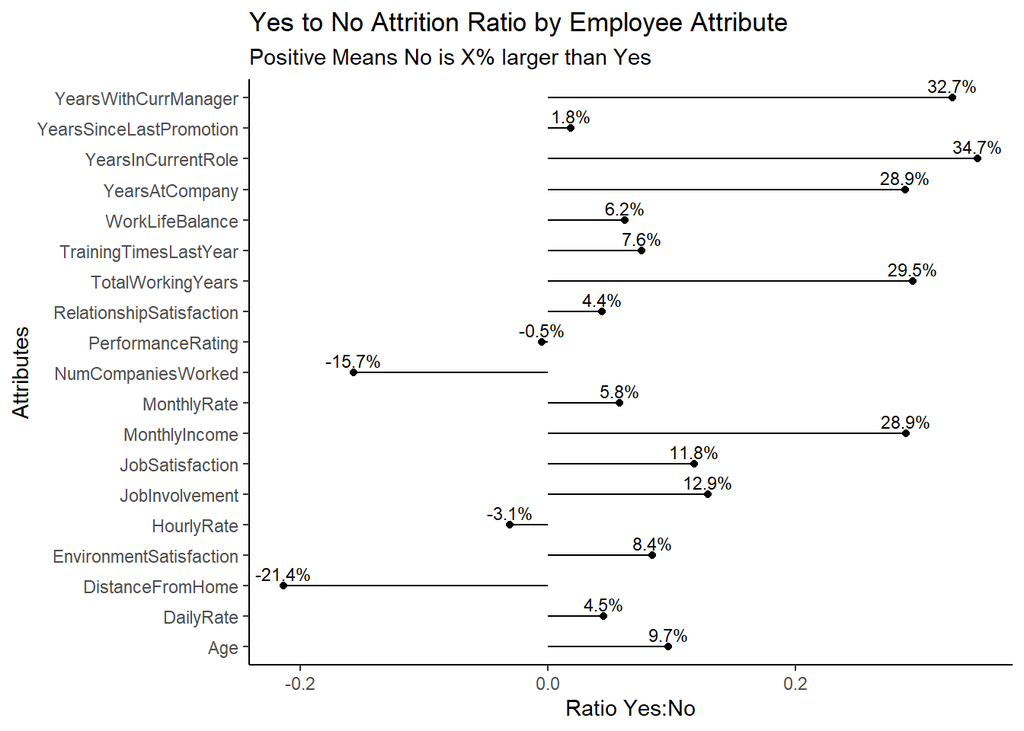

```r
Perc_Att$Percent <- Perc_Att$n/length(dds$Age)
# 83.9% No Attrition  16.1% Yes Attrition

# Let's look at some summaries overall and then of people that left the company
ddsSummary <- data.frame(summary(dds))
ddsSummary <- na.omit(ddsSummary)
ddsSummary <- ddsSummary %>% separate(Freq, into = c("Variable", "Value"), sep = ":")
ddsSummary <- ddsSummary[,-1]
ddsSummary <- ddsSummary %>% unite(Var, Var2, Variable, sep = " ")
#view(ddsSummary)

# Find summaries of attribution = "yes"
ddsSumAtt <- dds %>% dplyr::filter(Attrition == "Yes") %>%
  summary(dds)
ddsSumAtt <- as.data.frame(ddsSumAtt)
ddsSumAtt <- na.omit(ddsSumAtt)
ddsSumAtt <- ddsSumAtt %>% separate(Freq, into = c("Variable", "Value"), sep = ":")
ddsSumAtt <- ddsSumAtt[,-1]
ddsSumAtt <- ddsSumAtt %>% unite(Var, Var2, Variable, sep = " ")


# Find summaries of attribution = "no"
ddsSumAttNo <- dds %>% dplyr::filter(Attrition == "No") %>%
  summary(dds)
ddsSumAttNo <- as.data.frame(ddsSumAttNo)
ddsSumAttNo <- na.omit(ddsSumAttNo)
ddsSumAttNo <- ddsSumAttNo %>% separate(Freq, into = c("Variable", "Value"), sep = ":")
ddsSumAttNo <- ddsSumAttNo[,-1]
ddsSumAttNo <- ddsSumAttNo %>% unite(Var, Var2, Variable, sep = " ")


# Create one master Yes vs No for numeric values for comparison
ddsSumMerge <- merge(ddsSumAtt, ddsSumAttNo, by = "Var")
ddsSumMerge <- rename(ddsSumMerge, "Att=Yes"="Value.x", "Att=No" =  "Value.y")

ddsSumMerge <- ddsSumMerge[-c(1:6, 13:42, 49:54, 61:81, 88:90, 97:111,
                              130:132, 163:174),]
write.csv(ddsSumMerge, "SumMerge.csv")

ddsColMeansYes <- dds %>% dplyr::filter(Attrition == "Yes") %>%
  dplyr::select(Age, DailyRate, HourlyRate,
                                     MonthlyRate, DistanceFromHome,
                                     EnvironmentSatisfaction,
                                     JobInvolvement,
                                     JobSatisfaction,
                                     MonthlyIncome,
                                     NumCompaniesWorked,
                                     PerformanceRating,
                                     RelationshipSatisfaction,
                                     TotalWorkingYears,
                                     TrainingTimesLastYear,
                                     WorkLifeBalance,
                                     YearsAtCompany,
                                     YearsInCurrentRole,
                                     YearsSinceLastPromotion,
                                     YearsWithCurrManager) %>%
  colMeans()
#view(ddsColMeansYes)
ddsColMeansYes <- as.data.frame((ddsColMeansYes))

ddsColMeansNo <- dds %>% dplyr::filter(Attrition == "No") %>%
  dplyr::select(Age, DailyRate, HourlyRate,
                                     MonthlyRate, DistanceFromHome,
                                     EnvironmentSatisfaction,
                                     JobInvolvement,
                                     JobSatisfaction,
                                     MonthlyIncome,
                                     NumCompaniesWorked,
                                     PerformanceRating,
                                     RelationshipSatisfaction,
                                     TotalWorkingYears,
                                     TrainingTimesLastYear,
                                     WorkLifeBalance,
                                     YearsAtCompany,
                                     YearsInCurrentRole,
                                     YearsSinceLastPromotion,
                                     YearsWithCurrManager) %>%
  colMeans()

ddsColMeansNo <- as.data.frame((ddsColMeansNo))

ddsColMeans <- cbind(ddsColMeansYes, ddsColMeansNo)

ddsColMeans <- rename(ddsColMeans, "AttYes" = "(ddsColMeansYes)", "AttNo"="(ddsColMeansNo)")
ddsColMeans$Ratio <- (1 - ddsColMeans$AttYes / ddsColMeans$AttNo )
ddsColMeans$Diff <- ddsColMeans$AttNo - ddsColMeans$AttYes

ddsRN <- rownames(ddsColMeans)
ddsColMeans <- cbind(ddsRN, ddsColMeans)
ddsColMeans <- rename(ddsColMeans, "Attributes" = "ddsRN")
rownames(ddsColMeans) <- 1:nrow(ddsColMeans)

# Plot to show ratios between mean values of Att=Yes vs Att=No
ddsColMeans %>% ggplot(aes(x=Ratio, y=Attributes)) +
  geom_point() +
  geom_segment(aes(x=Ratio, xend=0, y=Attributes, yend=Attributes)) +
  labs(title = "Yes to No Attrition Ratio by Employee Attribute",
       subtitle = "Positive Means No is X% larger than Yes") +
  geom_text(aes(label=formattable::percent(Ratio,1)), size = 3, nudge_y = .4) +
  xlab("Ratio Yes:No") +
  theme_classic()
```

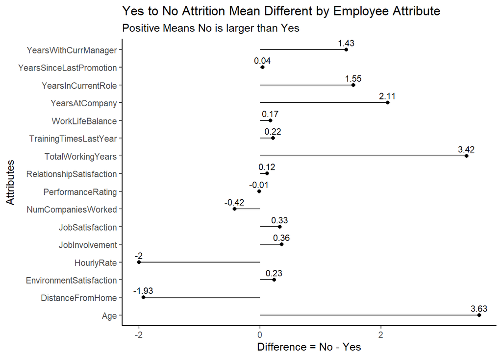

```r
# Plot to show differences in mean values of Att=Yes vs Att=No
ddsColMeans[-c(2,4,9),] %>%
  ggplot(aes(x=Diff, y=Attributes)) +
  geom_point() +
  geom_segment(aes(x=Diff, xend=0, y=Attributes, yend=Attributes)) +
  labs(title = "Yes to No Attrition Mean Different by Employee Attribute",
       subtitle = "Positive Means No is larger than Yes") +
  geom_text(aes(label=round(Diff, 2)), size = 3, nudge_y = .4) +
  xlab("Difference = No - Yes") +
  theme_classic()
```

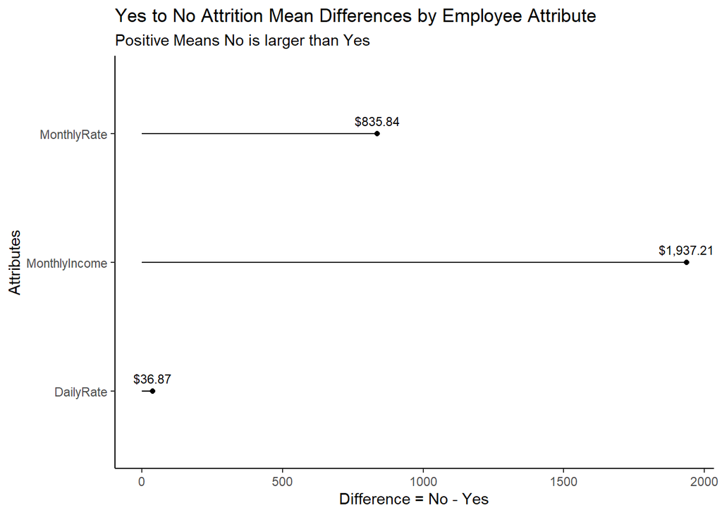

```r
# Plot to show differences in mean values of Att=Yes vs Att=No  for Earnings
ddsColMeans[c(2,4,9),] %>%
  ggplot(aes(x=Diff, y=Attributes)) +
  geom_point() +
  geom_segment(aes(x=Diff, xend=0, y=Attributes, yend=Attributes)) +
  labs(title = "Yes to No Attrition Mean Differences by Employee Attribute",
       subtitle = "Positive Means No is larger than Yes") +
  geom_text(aes(label=scales::dollar(round(Diff, 2))), size = 3, nudge_y = .1) +
  xlab("Difference = No - Yes") +
  theme_classic()
```

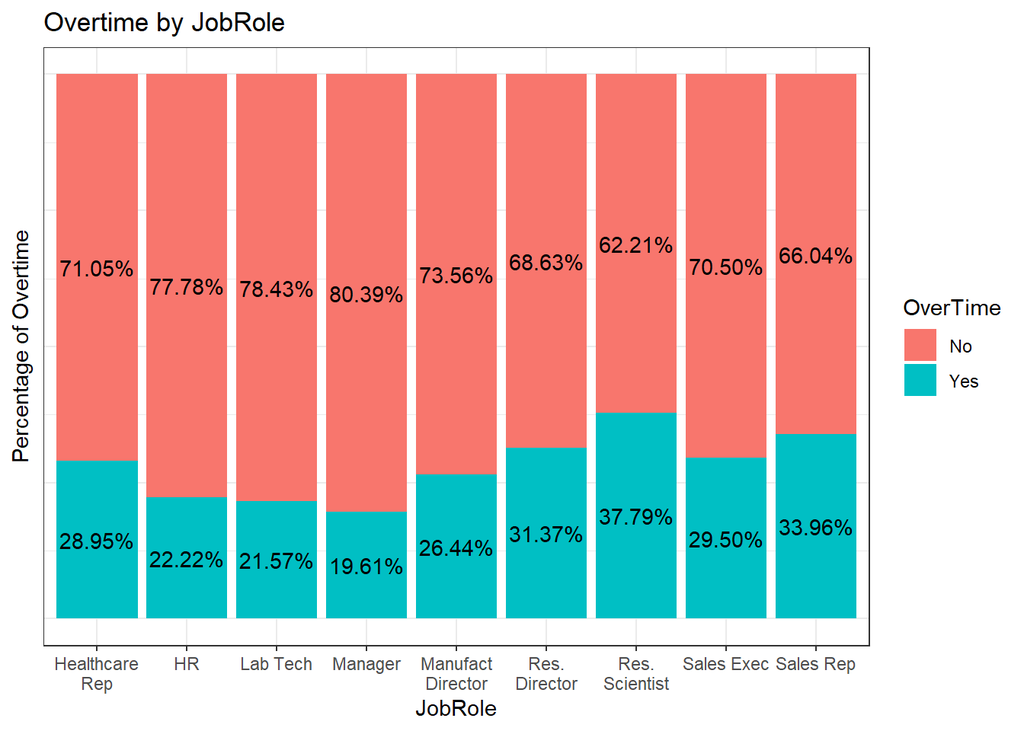

```r
##### Review the top 3 Factors that contribute to Attrition #####

############## Overtime #################################
# Plot Overtime by Percent vs Job Roles
ddsPlot <- ddsBinded %>% group_by(JobRole, OverTime) %>% #OT by JobRole
  summarize(count = n()) %>% # count recordc by JobRoles
  mutate(pct = count/sum(count)) # find percent total
# Overall OT for the company
OT <- ddsBinded %>% group_by(OverTime) %>%  #OT for whole dataset
  summarize(count = n()) %>% # count recordc by JobRoles
  mutate(pct = count/sum(count)) # find percent total
# plot the graph
ddsPlot %>%
  ggplot(aes(x=JobRole, y=pct, fill = OverTime)) +
  geom_bar(stat = "identity") +
  labs(title = "Overtime by JobRole",
       y="Percentage of Overtime",
       x="JobRole") +
  geom_text(aes(label=scales::percent(pct)), position = position_stack(vjust = .5)) +
  scale_x_discrete(labels = function(x) str_wrap(x, width=10)) +
  theme_bw() +
  theme(axis.text.y=element_blank(),
           axis.ticks.y=element_blank())
```

```r
OTValueYes <- ddsBinded %>% filter(OverTime == "Yes") %>%
  aggregate(MonthlyIncome~JobRole, ., mean)
OTValueNo <- ddsBinded %>% filter(OverTime == "No") %>%
  aggregate(MonthlyIncome~JobRole, ., mean)

aggOTV <- aggregate(MonthlyIncome~OverTime, ddsBinded, mean)
dff <- aggOTV$MonthlyIncome[1]-aggOTV$MonthlyIncome[2]
dff
```

```
## [1] 255.9768
```

```r
OTV <- merge(x=OTValueYes, y=OTValueNo, by = "JobRole")
names(OTV)[2] <- "OT:Yes Monthly Income"
names(OTV)[3] <- "OT:No Monthly Income"
OTV
```

```
##             JobRole OT:Yes Monthly Income OT:No Monthly Income
## 1    Healthcare Rep              7613.409             7362.796
## 2                HR              3581.333             3199.857
## 3          Lab Tech              3487.303             3148.858
## 4           Manager             16617.200            17338.610
## 5 Manufact Director              7876.609             7371.750
## 6     Res. Director             15632.312            15803.657
## 7    Res. Scientist              3342.862             3208.589
## 8        Sales Exec              6831.898             6916.837
## 9         Sales Rep              2369.000             2798.800
```

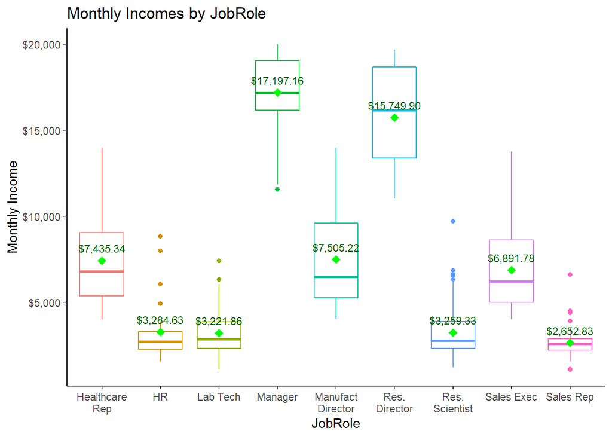

```r
####################  Monthly Income ################
# Look at MonthlyIncome
# Overall MonthlyIncomes for the company
Monthly <- ddsBinded %>% group_by() %>%  #OT for whole dataset
  summarize(count = n()) %>% # count recordc by JobRoles
  mutate(pct = count/sum(count)) # find percent total

# plot the graph
means <- aggregate(MonthlyIncome~JobRole, ddsBinded, mean)
ddsBinded %>%
  ggplot(aes(x=JobRole,y=MonthlyIncome)) +
  geom_boxplot(aes(color = JobRole), show.legend = FALSE) +
  labs(title = "Monthly Incomes by JobRole",
       y="Monthly Income",
       x="JobRole") +
  scale_y_continuous(labels=scales::dollar_format()) +
  #geom_text(aes(label=scales::percent(pct)), position = position_stack(vjust = .5)) +
  theme_classic() +
  stat_summary(fun=mean, color="green", geom="point",
               shape=18, size=3,show.legend = FALSE) +
  geom_text(data = means, aes(label = scales::dollar(MonthlyIncome)),vjust = -1, size=3, color="darkgreen") +
  scale_x_discrete(labels = function(x) str_wrap(x, width=10))
```

```r
############### Explore Stock options ###################
# Stock Option Levels by Job Role
Opts <- ddsBinded %>% group_by(JobRole, StockOptionLevel) %>% #Stock option levels by JobRole
  summarize(count = n()) %>% # count records by JobRoles
  mutate(pct = count/sum(count)) # find percent total
# Overall Stock Options Levels for the company
Stocks <- ddsBinded %>% group_by(StockOptionLevel) %>%  #stock options levels for whole dataset
  summarize(count = n()) %>% # count records by JobRoles
  mutate(pct = count/sum(count)) # find percent total
```

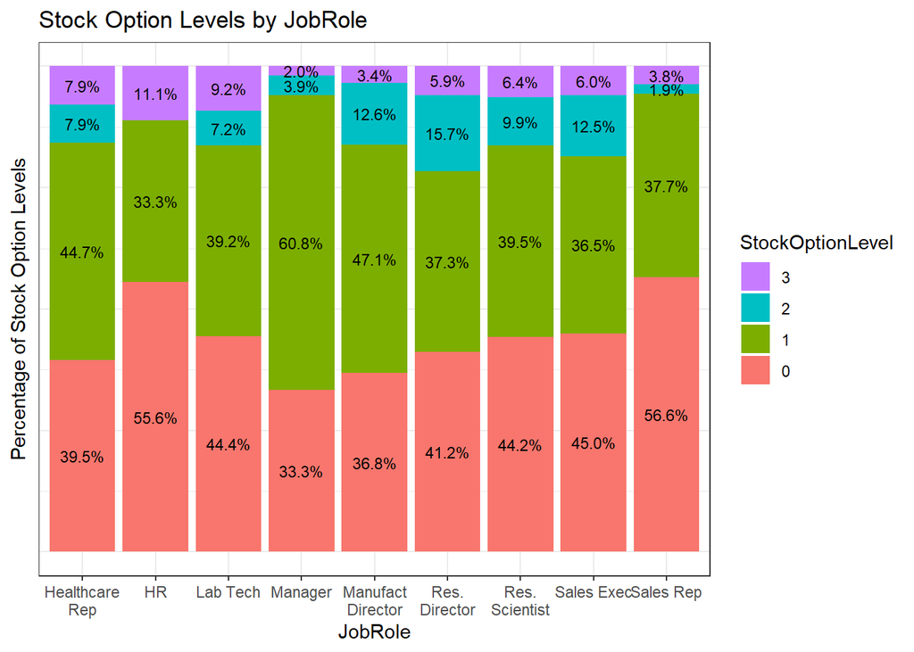

```r
# Plot Percentages

Opts %>%
  ggplot(aes(x=JobRole, y=pct, fill = StockOptionLevel)) +
  geom_bar(stat = "identity", position = position_stack(reverse = TRUE)) +
  labs(title = "Stock Option Levels by JobRole",
       y="Percentage of Stock Option Levels",
       x="JobRole") +
  geom_text(aes(label=scales::percent(pct, .1)), position = position_stack(vjust = .5, reverse = TRUE), size = 3) +
  scale_x_discrete(labels = function(x) str_wrap(x, width=10)) +
  scale_fill_discrete(guide=guide_legend(reverse = TRUE)) +
  theme_bw() +
  theme(axis.text.y=element_blank(),
           axis.ticks.y=element_blank())
```

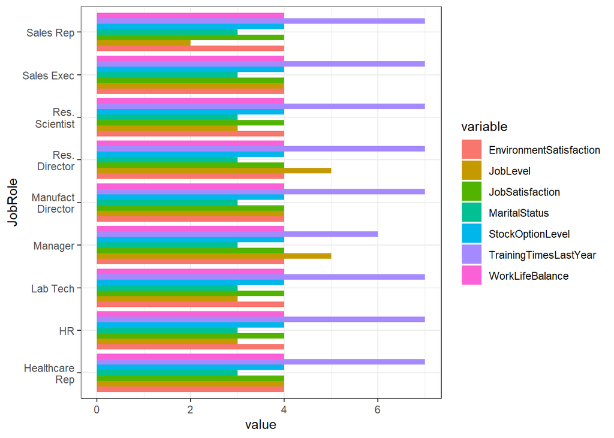

```r
#########  Job Specific Trends  ############

bbq <- ddsBinded
positions <- c(6,9,11,12,16,17,18)
bbq[,c(positions)] <- sapply(bbq[,c(positions)],as.numeric)
bbqPlot <- cbind(bbq$JobRole, bbq[,c(positions)])
names(bbqPlot)[1] <- "JobRole"
test = colMeans(bbqPlot[,c(2:8)])


# Plot each variable by JobRole
bbqPlot %>% pivot_longer(., cols=c(2:8), names_to = "variable", values_to="value") %>% #combines variables into one large variable
  ggplot(aes(x=JobRole, y=value, fill=variable)) +
  geom_bar(stat = "identity", position = "dodge", show.legend = TRUE) +
  theme_bw() +
  scale_x_discrete(labels = function(x) str_wrap(x, width=10)) +
  coord_flip()
```

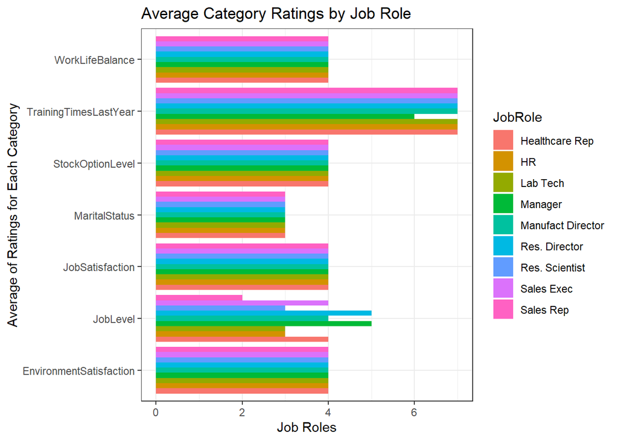

```r
# Plot each JobRole by Variable
bbqPlot %>% pivot_longer(., cols=c(2:8), names_to = "variable", values_to="value") %>% #combines variables into one large variable
  ggplot(aes(x=variable, y=value, fill=JobRole)) +
  geom_bar(stat = "identity", position = "dodge", show.legend = TRUE) +
  theme_bw() +
  scale_x_discrete(labels = function(x) str_wrap(x, width=10)) +
  coord_flip() +
  labs(title = "Average Category Ratings by Job Role",
       y = "Job Roles",
       x = "Average of Ratings for Each Category")
```

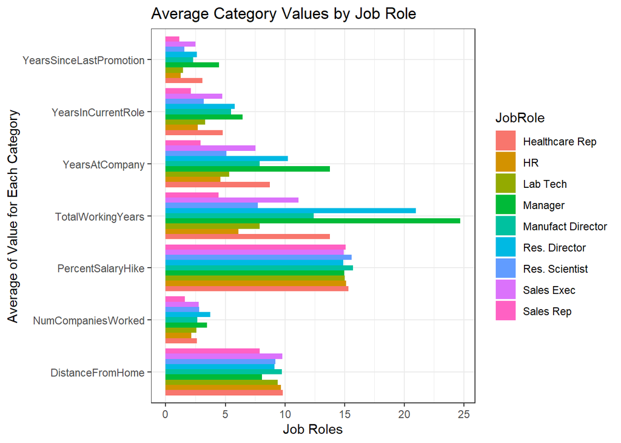

```r
### Plot the rest of the variables

bbqPlot2 <- bbq[,c(10, 21, 25:31)]
bbqPlot2 <- aggregate(.~JobRole, data=bbqPlot2, mean) #get colMeans for each variable by JobRole


# Plot each JobRole by Variable (age and monthly income should be run alone)
bbqPlot2 %>% pivot_longer(., cols=c(2:8), names_to = "variable", values_to="value") %>% #combines variables into one large variable
  ggplot(aes(x=variable, y=value, fill=JobRole)) +
  geom_bar(stat = "identity", position = "dodge", show.legend = TRUE) +
  theme_bw() +
  scale_x_discrete(labels = function(x) str_wrap(x, width=10)) +
  coord_flip() +
  labs(title = "Average Category Values by Job Role",
       y = "Job Roles",
       x = "Average of Value for Each Category")
```

```r
##############################
#                            #
##        Naive Bayes       ##
###      Model Fitting     ###
##                          ##
##############################

fritoLay <- ddsBinded[,c("Attrition",
                         "Department",
                         "JobInvolvement",
                         "JobLevel",
                         "JobRole",
                         "JobSatisfaction",
                         "MaritalStatus",
                         "OverTime",
                         "StockOptionLevel",
                         "WorkLifeBalance",
                         "Age",
                         "MonthlyIncome",
                         "NumCompaniesWorked",
                         "TotalWorkingYears",
                         "YearsAtCompany",
                         "YearsInCurrentRole",
                         "YearsWithCurrManager")]

iterations = 200

masterAcc = matrix(nrow = iterations)
masterSen <- matrix(nrow = iterations)
masterSpec <- matrix(nrow = iterations)

splitPerc = .7 #Training / Test split Percentage

for(j in 1:iterations)
{ trainInd = createDataPartition(fritoLay$Attrition, p = splitPerc, list = FALSE)
  train = fritoLay[trainInd,]
  test = fritoLay[-trainInd,]
  model = naiveBayes(train[,-1], train[,1], laplace = 0)
  table(predict(model,test[,-1]), test[,1])
  CM = confusionMatrix(table(predict(model,test[,-1]),test[,1]))
  masterAcc[j]  <-  CM$overall[1]
  masterSen[j]  <-  CM$byClass[1]
  masterSpec[j] <-  CM$byClass[2]
}

MeanAcc   <-  colMeans(masterAcc)
MeanSen   <-  colMeans(masterSen)
MeanSpec  <-  colMeans(masterSpec)
MeanAcc
```

```
## [1] 0.8069732
```

```r
MeanSen
```

```
## [1] 0.8458447
```

```r
MeanSpec
```

```
## [1] 0.6042857
```

```r
CM
```

```
## Confusion Matrix and Statistics
##
##
##        No Yes
##   No  182  15
##   Yes  37  27
##
##                Accuracy : 0.8008
##                  95% CI : (0.7471, 0.8475)
##     No Information Rate : 0.8391
##     P-Value [Acc > NIR] : 0.958464
##
##                   Kappa : 0.3911
##
##  Mcnemar's Test P-Value : 0.003589
##
##             Sensitivity : 0.8311
##             Specificity : 0.6429
##          Pos Pred Value : 0.9239
##          Neg Pred Value : 0.4219
##              Prevalence : 0.8391
##          Detection Rate : 0.6973
##    Detection Prevalence : 0.7548
##       Balanced Accuracy : 0.7370
##
##        'Positive' Class : No
##
```

```r
#### BOOOM WE are in the money! ###
# Accuracy : 0.8352
#                 95% CI : (0.7846, 0.8781)
#    No Information Rate : 0.8391
#    P-Value [Acc > NIR] : 0.6066
#
#                  Kappa : 0.4483
#
# Mcnemar's Test P-Value : 0.1273
#
#            Sensitivity : 0.8767
#            Specificity : 0.6190
#         Pos Pred Value : 0.9231
#         Neg Pred Value : 0.4906
#             Prevalence : 0.8391
#         Detection Rate : 0.7356
#   Detection Prevalence : 0.7969
#      Balanced Accuracy : 0.7479
#
```

```r
##############################
##                          ##
## Prepare the Competition  ##
##     Set of Data for      ##
##         Attrition        ##
##                          ##
##############################
compSet <- read.csv("CaseStudy2CompSet No Attrition.csv")
str(compSet)
```

```
## 'data.frame':    300 obs. of  35 variables:
##  $ ID                      : int  1171 1172 1173 1174 1175 1176 1177 1178 1179 1180 ...
##  $ Age                     : int  35 33 26 55 29 51 52 39 31 31 ...
##  $ BusinessTravel          : chr  "Travel_Rarely" "Travel_Rarely" "Travel_Rarely" "Travel_Rarely" ...
##  $ DailyRate               : int  750 147 1330 1311 1246 1456 585 1387 1062 534 ...
##  $ Department              : chr  "Research & Development" "Human Resources" "Research & Development" "Research & Development" ...
##  $ DistanceFromHome        : int  28 2 21 2 19 1 29 10 24 20 ...
##  $ Education               : int  3 3 3 3 3 4 4 5 3 3 ...
##  $ EducationField          : chr  "Life Sciences" "Human Resources" "Medical" "Life Sciences" ...
##  $ EmployeeCount           : int  1 1 1 1 1 1 1 1 1 1 ...
##  $ EmployeeNumber          : int  1596 1207 1107 505 1497 145 2019 1618 1252 587 ...
##  $ EnvironmentSatisfaction : int  2 2 1 3 3 1 1 2 3 1 ...
##  $ Gender                  : chr  "Male" "Male" "Male" "Female" ...
##  $ HourlyRate              : int  46 99 37 97 77 30 40 76 96 66 ...
##  $ JobInvolvement          : int  4 3 3 3 2 2 3 3 2 3 ...
```

[output cut: 21 more lines]

```r
#view(names(compSet))

sapply(compSet, function(x) sum(is.na(x)))
```

```
##                       ID                      Age           BusinessTravel
##                        0                        0                        0
##                DailyRate               Department         DistanceFromHome
##                        0                        0                        0
##                Education           EducationField            EmployeeCount
##                        0                        0                        0
##           EmployeeNumber  EnvironmentSatisfaction                   Gender
##                        0                        0                        0
##               HourlyRate           JobInvolvement                 JobLevel
##                        0                        0                        0
##                  JobRole          JobSatisfaction            MaritalStatus
##                        0                        0                        0
##            MonthlyIncome              MonthlyRate       NumCompaniesWorked
##                        0                        0                        0
##                   Over18                 OverTime        PercentSalaryHike
##                        0                        0                        0
##        PerformanceRating RelationshipSatisfaction            StandardHours
##                        0                        0                        0
##         StockOptionLevel        TotalWorkingYears    TrainingTimesLastYear
##                        0                        0                        0
##          WorkLifeBalance           YearsAtCompany       YearsInCurrentRole
##                        0                        0                        0
##  YearsSinceLastPromotion     YearsWithCurrManager
##                        0                        0
```

```r
# Confirmed no NA's in the data

# Categorical Variable Manipulation
comp_cat <- compSet[,c(3,5,7,8,11,12,14:18,23,25,26,28,30,31)]
str(comp_cat)
```

```
## 'data.frame':    300 obs. of  17 variables:
##  $ BusinessTravel          : chr  "Travel_Rarely" "Travel_Rarely" "Travel_Rarely" "Travel_Rarely" ...
##  $ Department              : chr  "Research & Development" "Human Resources" "Research & Development" "Research & Development" ...
##  $ Education               : int  3 3 3 3 3 4 4 5 3 3 ...
##  $ EducationField          : chr  "Life Sciences" "Human Resources" "Medical" "Life Sciences" ...
##  $ EnvironmentSatisfaction : int  2 2 1 3 3 1 1 2 3 1 ...
##  $ Gender                  : chr  "Male" "Male" "Male" "Female" ...
##  $ JobInvolvement          : int  4 3 3 3 2 2 3 3 2 3 ...
##  $ JobLevel                : int  2 1 1 4 2 3 1 2 2 3 ...
##  $ JobRole                 : chr  "Laboratory Technician" "Human Resources" "Laboratory Technician" "Manager" ...
##  $ JobSatisfaction         : int  3 3 3 4 3 1 4 1 1 3 ...
##  $ MaritalStatus           : chr  "Married" "Married" "Divorced" "Single" ...
##  $ OverTime                : chr  "No" "No" "No" "Yes" ...
##  $ PerformanceRating       : int  3 3 4 3 3 4 3 3 3 3 ...
##  $ RelationshipSatisfaction: int  4 4 3 3 3 3 2 4 2 1 ...
##  $ StockOptionLevel        : int  2 1 1 0 2 0 2 3 0 0 ...
##  $ TrainingTimesLastYear   : int  3 2 0 2 3 1 3 3 2 2 ...
##  $ WorkLifeBalance         : int  2 3 2 3 3 2 2 3 3 3 ...
```

```r
# let's turn all the variables into factors
comp_cat <- comp_cat %>% dplyr::mutate_if(is.character, as.factor)
comp_cat <- comp_cat %>% dplyr::mutate_if(is.integer, as.factor)
str(comp_cat)
```

```
## 'data.frame':    300 obs. of  17 variables:
##  $ BusinessTravel          : Factor w/ 3 levels "Non-Travel","Travel_Frequently",..: 3 3 3 3 3 2 1 3 3 2 ...
##  $ Department              : Factor w/ 3 levels "Human Resources",..: 2 1 2 2 3 2 3 2 2 2 ...
##  $ Education               : Factor w/ 5 levels "1","2","3","4",..: 3 3 3 3 3 4 4 5 3 3 ...
##  $ EducationField          : Factor w/ 6 levels "Human Resources",..: 2 1 4 2 2 4 2 4 4 2 ...
##  $ EnvironmentSatisfaction : Factor w/ 4 levels "1","2","3","4": 2 2 1 3 3 1 1 2 3 1 ...
##  $ Gender                  : Factor w/ 2 levels "Female","Male": 2 2 2 1 2 1 2 2 1 2 ...
##  $ JobInvolvement          : Factor w/ 4 levels "1","2","3","4": 4 3 3 3 2 2 3 3 2 3 ...
##  $ JobLevel                : Factor w/ 5 levels "1","2","3","4",..: 2 1 1 4 2 3 1 2 2 3 ...
##  $ JobRole                 : Factor w/ 9 levels "Healthcare Representative",..: 3 2 3 4 8 1 9 5 1 1 ...
##  $ JobSatisfaction         : Factor w/ 4 levels "1","2","3","4": 3 3 3 4 3 1 4 1 1 3 ...
##  $ MaritalStatus           : Factor w/ 3 levels "Divorced","Married",..: 2 2 1 3 1 3 1 2 3 2 ...
##  $ OverTime                : Factor w/ 2 levels "No","Yes": 1 1 1 2 1 1 1 1 1 1 ...
##  $ PerformanceRating       : Factor w/ 2 levels "3","4": 1 1 2 1 1 2 1 1 1 1 ...
##  $ RelationshipSatisfaction: Factor w/ 4 levels "1","2","3","4": 4 4 3 3 3 3 2 4 2 1 ...
##  $ StockOptionLevel        : Factor w/ 4 levels "0","1","2","3": 3 2 2 1 3 1 3 4 1 1 ...
##  $ TrainingTimesLastYear   : Factor w/ 7 levels "0","1","2","3",..: 4 3 1 3 4 2 4 4 3 3 ...
##  $ WorkLifeBalance         : Factor w/ 4 levels "1","2","3","4": 2 3 2 3 3 2 2 3 3 3 ...
```

```r
# Numerical Variable Manupulation
comp_num <- compSet[,c(2,4,6,13,19,20,21,24,29,32:35)]
#view(names(comp_num))
str(comp_num)
```

```
## 'data.frame':    300 obs. of  13 variables:
##  $ Age                    : int  35 33 26 55 29 51 52 39 31 31 ...
##  $ DailyRate              : int  750 147 1330 1311 1246 1456 585 1387 1062 534 ...
##  $ DistanceFromHome       : int  28 2 21 2 19 1 29 10 24 20 ...
##  $ HourlyRate             : int  46 99 37 97 77 30 40 76 96 66 ...
##  $ MonthlyIncome          : int  3407 3600 2377 16659 8620 7484 3482 5377 6812 9824 ...
##  $ MonthlyRate            : int  25348 8429 19373 23258 23757 25796 19788 3835 17198 22908 ...
##  $ NumCompaniesWorked     : int  1 1 1 2 1 3 2 2 1 3 ...
##  $ PercentSalaryHike      : int  17 13 20 13 14 20 15 13 19 12 ...
##  $ TotalWorkingYears      : int  10 5 1 30 10 23 16 10 10 12 ...
##  $ YearsAtCompany         : int  10 5 1 5 10 13 9 7 10 1 ...
##  $ YearsInCurrentRole     : int  9 4 1 4 7 12 8 7 9 0 ...
##  $ YearsSinceLastPromotion: int  6 1 0 1 0 12 0 7 1 0 ...
##  $ YearsWithCurrManager   : int  8 4 0 2 4 8 0 7 8 0 ...
```

```r
comp_num[,c(1:13)] <- sapply(comp_num[,c(1:13)], as.numeric)
str(comp_num)
```

```
## 'data.frame':    300 obs. of  13 variables:
##  $ Age                    : num  35 33 26 55 29 51 52 39 31 31 ...
##  $ DailyRate              : num  750 147 1330 1311 1246 ...
##  $ DistanceFromHome       : num  28 2 21 2 19 1 29 10 24 20 ...
##  $ HourlyRate             : num  46 99 37 97 77 30 40 76 96 66 ...
##  $ MonthlyIncome          : num  3407 3600 2377 16659 8620 ...
##  $ MonthlyRate            : num  25348 8429 19373 23258 23757 ...
##  $ NumCompaniesWorked     : num  1 1 1 2 1 3 2 2 1 3 ...
##  $ PercentSalaryHike      : num  17 13 20 13 14 20 15 13 19 12 ...
##  $ TotalWorkingYears      : num  10 5 1 30 10 23 16 10 10 12 ...
##  $ YearsAtCompany         : num  10 5 1 5 10 13 9 7 10 1 ...
##  $ YearsInCurrentRole     : num  9 4 1 4 7 12 8 7 9 0 ...
##  $ YearsSinceLastPromotion: num  6 1 0 1 0 12 0 7 1 0 ...
##  $ YearsWithCurrManager   : num  8 4 0 2 4 8 0 7 8 0 ...
```

```r
# Recombine the variable sets
compSetFormatted <- cbind(comp_cat, comp_num)
str(compSetFormatted)
```

```
## 'data.frame':    300 obs. of  30 variables:
##  $ BusinessTravel          : Factor w/ 3 levels "Non-Travel","Travel_Frequently",..: 3 3 3 3 3 2 1 3 3 2 ...
##  $ Department              : Factor w/ 3 levels "Human Resources",..: 2 1 2 2 3 2 3 2 2 2 ...
##  $ Education               : Factor w/ 5 levels "1","2","3","4",..: 3 3 3 3 3 4 4 5 3 3 ...
##  $ EducationField          : Factor w/ 6 levels "Human Resources",..: 2 1 4 2 2 4 2 4 4 2 ...
##  $ EnvironmentSatisfaction : Factor w/ 4 levels "1","2","3","4": 2 2 1 3 3 1 1 2 3 1 ...
##  $ Gender                  : Factor w/ 2 levels "Female","Male": 2 2 2 1 2 1 2 2 1 2 ...
##  $ JobInvolvement          : Factor w/ 4 levels "1","2","3","4": 4 3 3 3 2 2 3 3 2 3 ...
##  $ JobLevel                : Factor w/ 5 levels "1","2","3","4",..: 2 1 1 4 2 3 1 2 2 3 ...
##  $ JobRole                 : Factor w/ 9 levels "Healthcare Representative",..: 3 2 3 4 8 1 9 5 1 1 ...
##  $ JobSatisfaction         : Factor w/ 4 levels "1","2","3","4": 3 3 3 4 3 1 4 1 1 3 ...
##  $ MaritalStatus           : Factor w/ 3 levels "Divorced","Married",..: 2 2 1 3 1 3 1 2 3 2 ...
##  $ OverTime                : Factor w/ 2 levels "No","Yes": 1 1 1 2 1 1 1 1 1 1 ...
##  $ PerformanceRating       : Factor w/ 2 levels "3","4": 1 1 2 1 1 2 1 1 1 1 ...
##  $ RelationshipSatisfaction: Factor w/ 4 levels "1","2","3","4": 4 4 3 3 3 3 2 4 2 1 ...
```

[output cut: 16 more lines]

```r
names(compSetFormatted)
```

```
##  [1] "BusinessTravel"           "Department"
##  [3] "Education"                "EducationField"
##  [5] "EnvironmentSatisfaction"  "Gender"
##  [7] "JobInvolvement"           "JobLevel"
##  [9] "JobRole"                  "JobSatisfaction"
## [11] "MaritalStatus"            "OverTime"
## [13] "PerformanceRating"        "RelationshipSatisfaction"
## [15] "StockOptionLevel"         "TrainingTimesLastYear"
## [17] "WorkLifeBalance"          "Age"
## [19] "DailyRate"                "DistanceFromHome"
## [21] "HourlyRate"               "MonthlyIncome"
## [23] "MonthlyRate"              "NumCompaniesWorked"
## [25] "PercentSalaryHike"        "TotalWorkingYears"
## [27] "YearsAtCompany"           "YearsInCurrentRole"
## [29] "YearsSinceLastPromotion"  "YearsWithCurrManager"
```

```r
# Reduce the Competition Set to the appropriate variables
compSetFinal <- compSetFormatted[,c("Department",
                                    "JobInvolvement",
                                    "JobLevel",
                                    "JobRole",
                                    "JobSatisfaction",
                                    "MaritalStatus",
                                    "OverTime",
                                    "StockOptionLevel",
                                    "WorkLifeBalance",
                                    "Age",
                                    "MonthlyIncome",
                                    "NumCompaniesWorked",
                                    "TotalWorkingYears",
                                    "YearsAtCompany",
                                    "YearsInCurrentRole",
                                    "YearsWithCurrManager")]

str(compSetFinal)
```

```
## 'data.frame':    300 obs. of  16 variables:
##  $ Department          : Factor w/ 3 levels "Human Resources",..: 2 1 2 2 3 2 3 2 2 2 ...
##  $ JobInvolvement      : Factor w/ 4 levels "1","2","3","4": 4 3 3 3 2 2 3 3 2 3 ...
##  $ JobLevel            : Factor w/ 5 levels "1","2","3","4",..: 2 1 1 4 2 3 1 2 2 3 ...
##  $ JobRole             : Factor w/ 9 levels "Healthcare Representative",..: 3 2 3 4 8 1 9 5 1 1 ...
##  $ JobSatisfaction     : Factor w/ 4 levels "1","2","3","4": 3 3 3 4 3 1 4 1 1 3 ...
##  $ MaritalStatus       : Factor w/ 3 levels "Divorced","Married",..: 2 2 1 3 1 3 1 2 3 2 ...
##  $ OverTime            : Factor w/ 2 levels "No","Yes": 1 1 1 2 1 1 1 1 1 1 ...
##  $ StockOptionLevel    : Factor w/ 4 levels "0","1","2","3": 3 2 2 1 3 1 3 4 1 1 ...
##  $ WorkLifeBalance     : Factor w/ 4 levels "1","2","3","4": 2 3 2 3 3 2 2 3 3 3 ...
##  $ Age                 : num  35 33 26 55 29 51 52 39 31 31 ...
##  $ MonthlyIncome       : num  3407 3600 2377 16659 8620 ...
##  $ NumCompaniesWorked  : num  1 1 1 2 1 3 2 2 1 3 ...
##  $ TotalWorkingYears   : num  10 5 1 30 10 23 16 10 10 12 ...
##  $ YearsAtCompany      : num  10 5 1 5 10 13 9 7 10 1 ...
##  $ YearsInCurrentRole  : num  9 4 1 4 7 12 8 7 9 0 ...
##  $ YearsWithCurrManager: num  8 4 0 2 4 8 0 7 8 0 ...
```

```r
##########################################
###                                    ###
### Run the Model to Predict Attrition ###
###                                    ###
##########################################

PredictAtt <- as.data.frame(predict(model, compSetFinal))
PredictAtt <- cbind(compSet$ID, PredictAtt)
colnames(PredictAtt) <- c("Model", "Attrition")
head(PredictAtt)
```

```
##   Model Attrition
## 1  1171        No
## 2  1172        No
## 3  1173        No
## 4  1174        No
## 5  1175        No
## 6  1176        No
```

```r
#write.csv(PredictAtt, "Case2PredictionsEhly Attrition.csv")
```

```r
##############################################
##                                          ##
##    Boruta for Monthly Incomes (Salary)   ##
##                                          ##
##############################################

MonInc <- cbind(dds$ID, ddsDF_num, ddsDF_cat)
str(MonInc)
```

```
## 'data.frame':    870 obs. of  33 variables:
##  $ dds$ID                  : int  1 2 3 4 5 6 7 8 9 10 ...
##  $ Attrition               : Factor w/ 2 levels "No","Yes": 1 1 1 1 1 1 1 1 1 1 ...
##  $ Age                     : num  32 40 35 32 24 27 41 37 34 34 ...
##  $ DailyRate               : num  117 1308 200 801 567 ...
##  $ DistanceFromHome        : num  13 14 18 1 2 10 5 10 10 10 ...
##  $ HourlyRate              : num  73 44 60 48 32 32 90 88 87 92 ...
##  $ MonthlyIncome           : num  4403 19626 9362 10422 3760 ...
##  $ MonthlyRate             : num  9250 17544 19944 24032 17218 ...
##  $ NumCompaniesWorked      : num  2 1 2 1 1 1 2 2 1 1 ...
##  $ PercentSalaryHike       : num  11 14 11 19 13 21 12 14 19 14 ...
##  $ TotalWorkingYears       : num  8 21 10 14 6 9 7 8 1 8 ...
##  $ YearsAtCompany          : num  5 20 2 14 6 9 4 1 1 8 ...
##  $ YearsInCurrentRole      : num  2 7 2 10 3 7 2 0 1 2 ...
##  $ YearsSinceLastPromotion : num  0 4 2 5 1 1 0 0 0 7 ...
```

[output cut: 19 more lines]

```r
names(MonInc)[1] <- "ID"
names(MonInc)
```

```
##  [1] "ID"                       "Attrition"
##  [3] "Age"                      "DailyRate"
##  [5] "DistanceFromHome"         "HourlyRate"
##  [7] "MonthlyIncome"            "MonthlyRate"
##  [9] "NumCompaniesWorked"       "PercentSalaryHike"
## [11] "TotalWorkingYears"        "YearsAtCompany"
## [13] "YearsInCurrentRole"       "YearsSinceLastPromotion"
## [15] "YearsWithCurrManager"     "Attrition"
## [17] "BusinessTravel"           "Department"
## [19] "Education"                "EducationField"
## [21] "EnvironmentSatisfaction"  "Gender"
## [23] "JobInvolvement"           "JobLevel"
## [25] "JobRole"                  "JobSatisfaction"
## [27] "MaritalStatus"            "OverTime"
## [29] "PerformanceRating"        "RelationshipSatisfaction"
## [31] "StockOptionLevel"         "TrainingTimesLastYear"
## [33] "WorkLifeBalance"
```

```r
MonInc <- MonInc[,-2]
MonInc$ID <- as.numeric(MonInc$ID)

boruta_moninc <- Boruta(MonthlyIncome~., data=MonInc, doTrace=2) # Boruta search
```

[output not shown]

[output not shown]

[output not shown]

[output not shown]

[output not shown]

[output not shown]

[output not shown]

[output not shown]

[output not shown]

[output not shown]

[output not shown]

[output not shown]

```
## After 12 iterations, +2.2 secs:
```

```
##  confirmed 10 attributes: Age, Department, JobLevel, JobRole, NumCompaniesWorked and 5 more;
```

```
##  rejected 15 attributes: DailyRate, EnvironmentSatisfaction, Gender, HourlyRate, ID and 10 more;
```

```
##  still have 6 attributes left.
```

[output not shown]

[output not shown]

[output not shown]

[output not shown]

```
## After 16 iterations, +2.7 secs:
```

```
##  rejected 2 attributes: DistanceFromHome, MonthlyRate;
```

```
##  still have 4 attributes left.
```

[output not shown]

[output not shown]

[output not shown]

[output not shown]

[output not shown]

[output not shown]

[output not shown]

[output not shown]

[output not shown]

[output not shown]

[output not shown]

[output not shown]

[output not shown]

[output not shown]

[output not shown]

[output not shown]

```
## After 32 iterations, +4.3 secs:
```

```
##  rejected 1 attribute: EducationField;
```

```
##  still have 3 attributes left.
```

[output not shown]

[output not shown]

[output not shown]

[output not shown]

[output not shown]

[output not shown]

```
## After 38 iterations, +4.8 secs:
```

```
##  confirmed 1 attribute: Attrition;
```

```
##  still have 2 attributes left.
```

[output not shown]

[output not shown]

[output not shown]

[output not shown]

[output not shown]

[output not shown]

[output not shown]

[output not shown]

[output not shown]

[output not shown]

[output not shown]

[output not shown]

[output not shown]

[output not shown]

[output not shown]

[output not shown]

[output not shown]

[output not shown]

[output not shown]

[output not shown]

[output not shown]

[output not shown]

[output not shown]

[output not shown]

[output not shown]

[output not shown]

[output not shown]

[output not shown]

[output not shown]

[output not shown]

[output not shown]

[output not shown]

[output not shown]

[output not shown]

[output not shown]

[output not shown]

[output not shown]

[output not shown]

[output not shown]

[output not shown]

[output not shown]

[output not shown]

[output not shown]

[output not shown]

```
## After 82 iterations, +8.8 secs:
```

```
##  confirmed 1 attribute: Education;
```

```
##  still have 1 attribute left.
```

[output not shown]

[output not shown]

[output not shown]

[output not shown]

[output not shown]

[output not shown]

[output not shown]

[output not shown]

[output not shown]

[output not shown]

[output not shown]

[output not shown]

[output not shown]

[output not shown]

[output not shown]

[output not shown]

[output not shown]

```r
boruta_sigMonInc <- names(boruta_moninc$finalDecision[boruta_moninc$finalDecision %in% c("Confirmed", "Tentative")]) #collect Confirmed and Tentative variables

print(boruta_sigMonInc) #view sig var
```

```
##  [1] "Age"                     "NumCompaniesWorked"
##  [3] "TotalWorkingYears"       "YearsAtCompany"
##  [5] "YearsInCurrentRole"      "YearsSinceLastPromotion"
##  [7] "YearsWithCurrManager"    "Attrition"
##  [9] "BusinessTravel"          "Department"
## [11] "Education"               "JobLevel"
## [13] "JobRole"
```

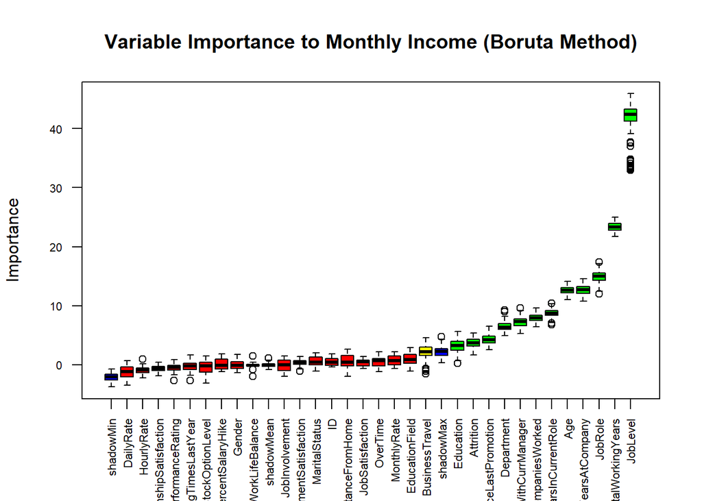

```r
plot(boruta_moninc, cex.axis=.7, las=2, xlab="", main="Variable Importance to Monthly Income (Boruta Method)") #plot results
```

```r
# Most Important Variables
# [1] "Age"                     "NumCompaniesWorked"      "TotalWorkingYears"       "YearsAtCompany"
# [5] "YearsInCurrentRole"      "YearsSinceLastPromotion" "YearsWithCurrManager"    "Attrition"
# [9] "BusinessTravel"          "Department"              "Education"               "JobLevel"
# [13] "JobRole"
```